# dask-image: distributed image processing for large data

## Presenter: Genevieve Buckley

# Who needs dask-image?

If you're using `numpy` and/or `scipy.ndimage` and are running out of RAM, dask-image is for you.

## Two main use cases

1. Batch processing
2. Large field of view

# Motivating examples

- Sentinel satellite data
- Individual neurons within the brain

[figure not shown]

# Getting started

https://github.com/dask/dask-image/

## conda

```
conda install -c conda-forge dask-image
```

## pip

```
pip install dask-image
```

# What's included?

- imread
- ndfilters
- ndfourier
- ndmorph
- ndmeasure

# Function coverage

[figure not shown]

# GPU support

Latest release includes GPU support for the modules:

- ndfilters
- imread

Still to do: ndfourier, ndmeasure, ndmorph*

*Done, pending cupy PR #3907

# GPU benchmarking

| Architecture | Time |
| --- | --- |
| Single CPU Core | 2hr 39min |
| Forty CPU Cores | 11min 30s |
| One GPU | 1min 37s |
| Eight GPUs | 19s |

https://blog.dask.org/2019/01/03/dask-array-gpus-first-steps

# Let's build a pipeline!

1. Reading in data
2. Filtering images
3. Segmenting objects
4. Morphological operations
5. Measuring objects

```python
%gui qt
```

We used image set [BBBC039v1](https://bbbc.broadinstitute.org/bbbc/BBBC039) Caicedo et al. 2018, available from the Broad Bioimage Benchmark Collection [Ljosa et al., Nature Methods, 2012](http://dx.doi.org/10.1038/nmeth.2083).

https://bbbc.broadinstitute.org/BBBC039

[figure not shown]

# 1. Reading in data

```python
from dask_image.imread import imread

images = imread('data/BBBC039/images/*.tif')
# images_on_gpu = imread('data/BBBC039/images/*.tif', arraytype="cupy")

images
```

|  | Array | Chunk |
| --- | --- | --- |
| Bytes | 144.77 MB | 723.84 kB |
| Shape | (200, 520, 696) | (1, 520, 696) |
| Count | 600 Tasks | 200 Chunks |
| Type | uint16 | numpy.ndarray |

[figure not shown]

# 2. Filtering images

Denoising images with a small blur can improve segmentation later on.

```python
from dask_image import ndfilters

smoothed = ndfilters.gaussian_filter(images, sigma=[0, 1, 1])
```

# 3. Segmenting objects

Pixels below the threshold value are background.

```python
absolute_threshold = smoothed > 160
```

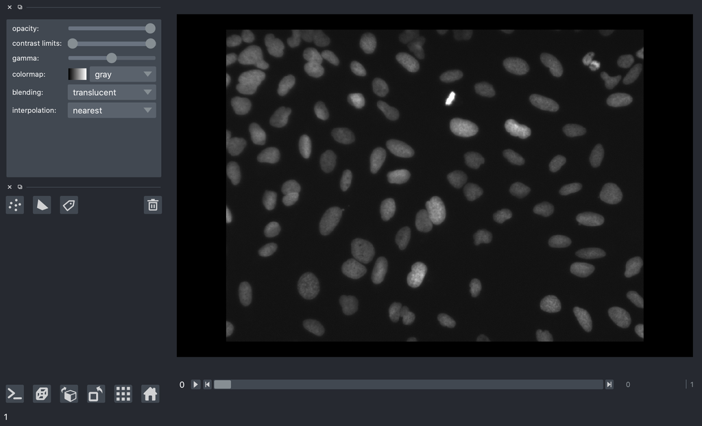

```python
# Let's have a look at the images
import napari
from napari.utils import nbscreenshot

viewer = napari.Viewer()
viewer.add_image(absolute_threshold)
viewer.add_image(images, contrast_limits=[0, 2000])
nbscreenshot(viewer)
```

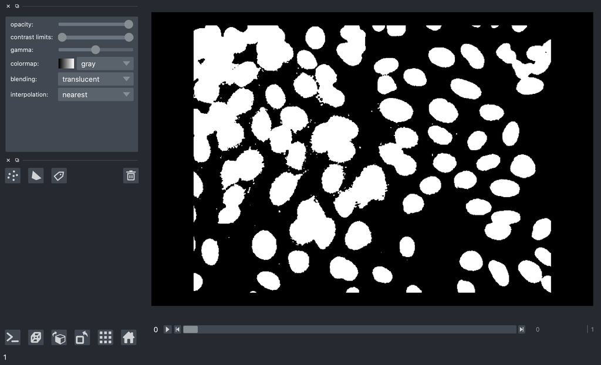

```python
viewer.layers[-1].visible = False
napari.utils.nbscreenshot(viewer)
```

# 3. Segmenting objects (continued)

A better segmentation using local thresholding.

```python
thresh = ndfilters.threshold_local(smoothed, images.chunksize)
threshold_images = smoothed > thresh
```

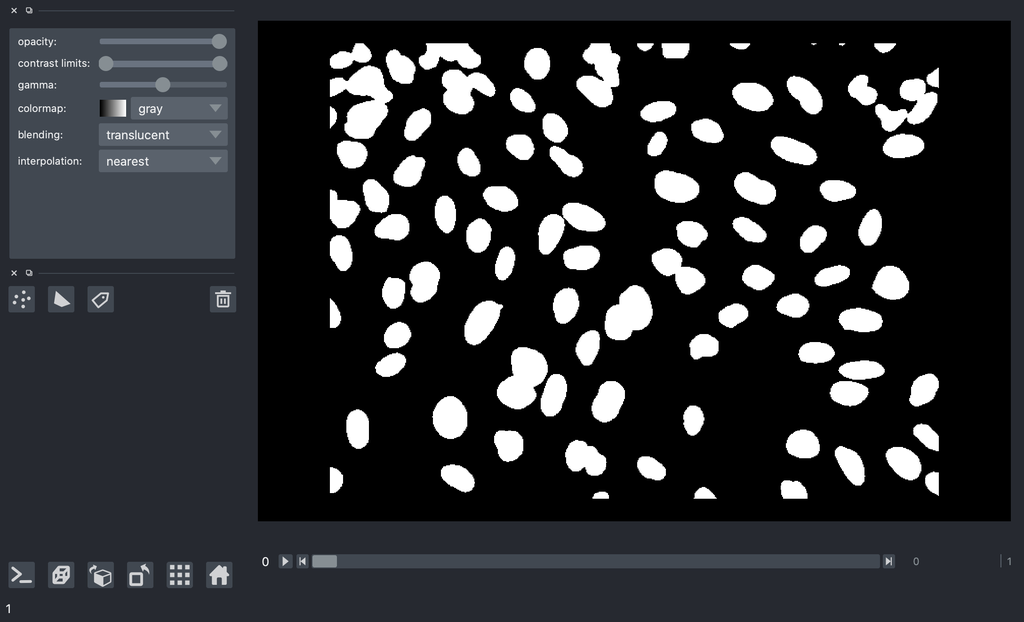

```python
# Let's take a look at the images
viewer.add_image(threshold_images)
nbscreenshot(viewer)
```

# 4. Morphological operations

These are operations on the shape of a binary image.

https://docs.opencv.org/3.0-beta/doc/py_tutorials/py_imgproc/py_morphological_ops/py_morphological_ops.html

## Erosion

[figure not shown]

## Dilation

[figure not shown]

A morphological opening operation is an erosion, followed by a dilation.

[figure not shown]

```python
from dask_image import ndmorph
import numpy as np

structuring_element = np.array([
    [[0, 0, 0], [0, 0, 0], [0, 0, 0]],
    [[0, 1, 0], [1, 1, 1], [0, 1, 0]],
    [[0, 0, 0], [0, 0, 0], [0, 0, 0]]])
binary_images = ndmorph.binary_opening(threshold_images, structure=structuring_element)
```

# 5. Measuring objects

Each image has many individual nuclei, so for the sake of time we'll measure a small subset of the data.

```python
from dask_image import ndmeasure

# Create labelled mask
label_images, num_features = ndmeasure.label(binary_images[:3], structuring_element)
index = np.arange(num_features - 1) + 1  # [1, 2, 3, ...num_features]
print("Number of nuclei:", num_features.compute())
```

```
Number of nuclei: 271
```

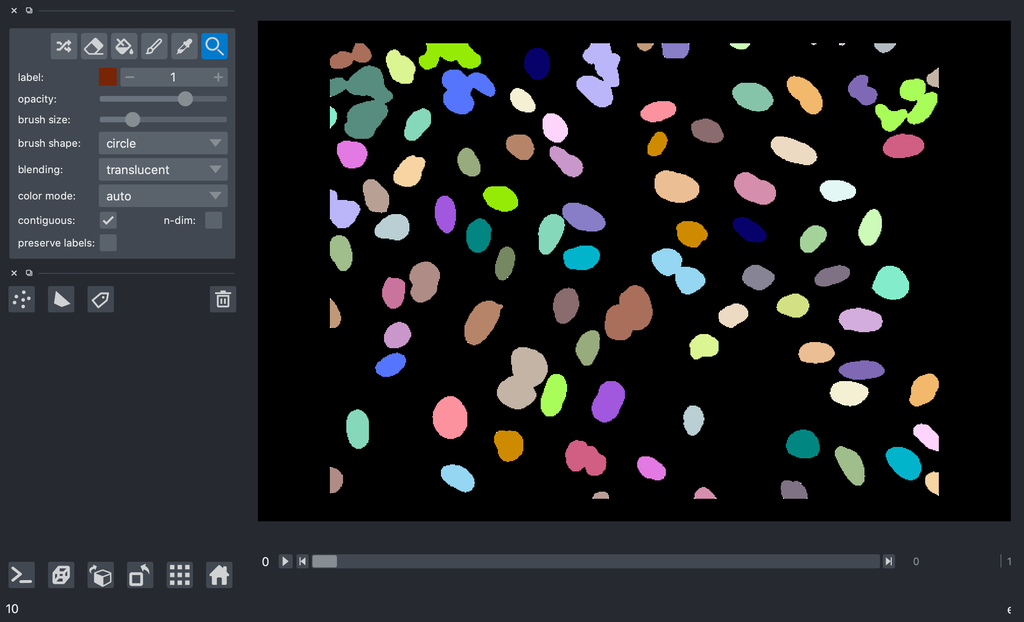

```python
# Let's look at the labels
viewer.add_labels(label_images)
viewer.dims.set_point(0, 0)
nbscreenshot(viewer)
```

# Measuring objects (continued)

```python
# Measure objects in images
area = ndmeasure.area(images[:3], label_images, index)
mean_intensity = ndmeasure.mean(images[:3], label_images, index)
```

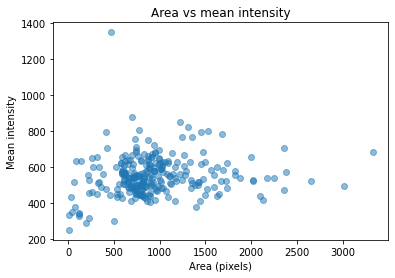

```python
# Run computation and plot results
import matplotlib.pyplot as plt

plt.scatter(area, mean_intensity, alpha=0.5)
plt.gca().update(dict(title="Area vs mean intensity", xlabel='Area (pixels)', ylabel='Mean intensity'))
plt.show()
```

```python
viewer.close()  # close the napari viewer
```

# The full pipeline

```
import numpy as np
from dask_image.imread import imread
from dask_image import ndfilters, ndmorph, ndmeasure

images = imread('data/BBBC039/images/*.tif')
smoothed = ndfilters.gaussian_filter(images, sigma=[0, 1, 1])
thresh = ndfilters.threshold_local(smoothed, blocksize=images.chunksize)
threshold_images = smoothed > thresh
structuring_element = np.array([[[0, 0, 0], [0, 0, 0], [0, 0, 0]], [[0, 1, 0], [1, 1, 1], [0, 1, 0]], [[0, 0, 0], [0, 0, 0], [0, 0, 0]]])
binary_images = ndmorph.binary_closing(threshold_image)
label_images, num_features = ndmeasure.label(binary_image)
index = np.arange(num_features)
area = ndmeasure.area(images, label_images, index)
mean_intensity = ndmeasure.mean(images, label_images, index)
```

# Custom functions

What if you want to do something that isn't included?

- scikit-image [apply_parallel()](https://scikit-image.org/docs/dev/api/skimage.util.html#skimage.util.apply_parallel)
- dask map_overlap / map_blocks
- dask [delayed](https://docs.dask.org/en/latest/delayed.html)

# Scaling up computation

Use [dask-distributed](https://distributed.dask.org/en/latest/) to scale up from a laptop onto a supercomputing cluster.

```
from dask.distributed import Client

# Setup a local cluster
# By default this sets up 1 worker per core
client = Client()
client.cluster
```

# dask-image

- Install: `conda` or `pip install dask-image`
- Documentation: https://dask-image.readthedocs.io
- GitHub: https://github.com/dask/dask-image/

[figure not shown]

# Bonus content

## Example using arrays on GPU

```
# CPU example
import numpy as np
import dask.array as da
from dask_image.ndfilters import convolve

s = (10, 10)
a = da.from_array(np.arange(int(np.prod(s))).reshape(s), chunks=5)
w = np.ones(a.ndim * (3,), dtype=np.float32)
result = convolve(a, w)
result.compute()
```

```
# Same example moved to the GPU
import cupy  # <- import cupy instead of numpy (version >=7.7.0)
import dask.array as da
from dask_image.ndfilters import convolve

s = (10, 10)
a = da.from_array(cupy.arange(int(cupy.prod(cupy.array(s)))).reshape(s), chunks=5)  # <- cupy dask array
w = cupy.ones(a.ndim * (3,))  # <- cupy dask array
result = convolve(a, w)
result.compute()
```